# Simulations of estimating causal effects using undersmoothed HAL

Seraphina Shi

2022-09-06

# Simulation #1

Data structure: $O = (W, A, Z, Y)$

- U - exogenous variables
- W - baseline covariate that is a measure of body condition
- A - treatment level based on W, continuous between 0 and 5
- Z - intermediate curve based on W and A
- Y - outcome, indicator of an event ?

Underlying data generating process, $P_{U,X}$

- Exogenous variables:
  - $U_A \sim Normal(\mu=0, \sigma^2 = 1^2)$
  - $U_A \sim Normal(\mu=0, \sigma^2 = 2^2)$
  - $U_Z \sim Uniform(min = 0, max = 1)$
  - $U_Y \sim Uniform(min = 0, max = 1)$
- Structural equations F and endogenous variables:
  - $W = U_W$
  - $A = bound(2 - 0.5W + U_A, min=0, max=5)$
  - $Z = \mathbf{I}[U_Z < expit(2-W-A)]$
  - $Y = \mathbf{I}[U_Y < expit(W + 5*A + Z - 0.5 * W * A - 8)]$

```
##        W                   A                Z                Y
##  Min.   :-3.864096   Min.   :0.0000   Min.   :0.0000   Min.   :0.0000
##  1st Qu.:-0.683312   1st Qu.:0.5552   1st Qu.:0.0000   1st Qu.:0.0000
##  Median : 0.011496   Median :1.9500   Median :0.0000   Median :1.0000
##  Mean   : 0.001781   Mean   :2.0854   Mean   :0.4929   Mean   :0.5914
##  3rd Qu.: 0.670664   3rd Qu.:3.3527   3rd Qu.:1.0000   3rd Qu.:1.0000
##  Max.   : 3.643275   Max.   :5.0000   Max.   :1.0000   Max.   :1.0000
```

```
## Summary of A given W < -1:
```

```
##    Min. 1st Qu.  Median    Mean 3rd Qu.    Max.
##   0.000   1.330   2.808   2.703   4.145   5.000
```

```
## Summary of A given -1 < W <= 0:
```

```
##    Min. 1st Qu.  Median    Mean 3rd Qu.    Max.
##  0.0000  0.8952  2.1717  2.2519  3.4960  5.0000
```

```
## Summary of A given 0 < W <= 1:
```

```
##    Min. 1st Qu.  Median    Mean 3rd Qu.    Max.
##  0.0000  0.3792  1.7255  1.9016  3.0540  5.0000
```

```
## Summary of A given 1 < W:
```

```
##    Min. 1st Qu.  Median    Mean 3rd Qu.    Max.
##   0.000   0.000   1.219   1.517   2.569   5.000
```

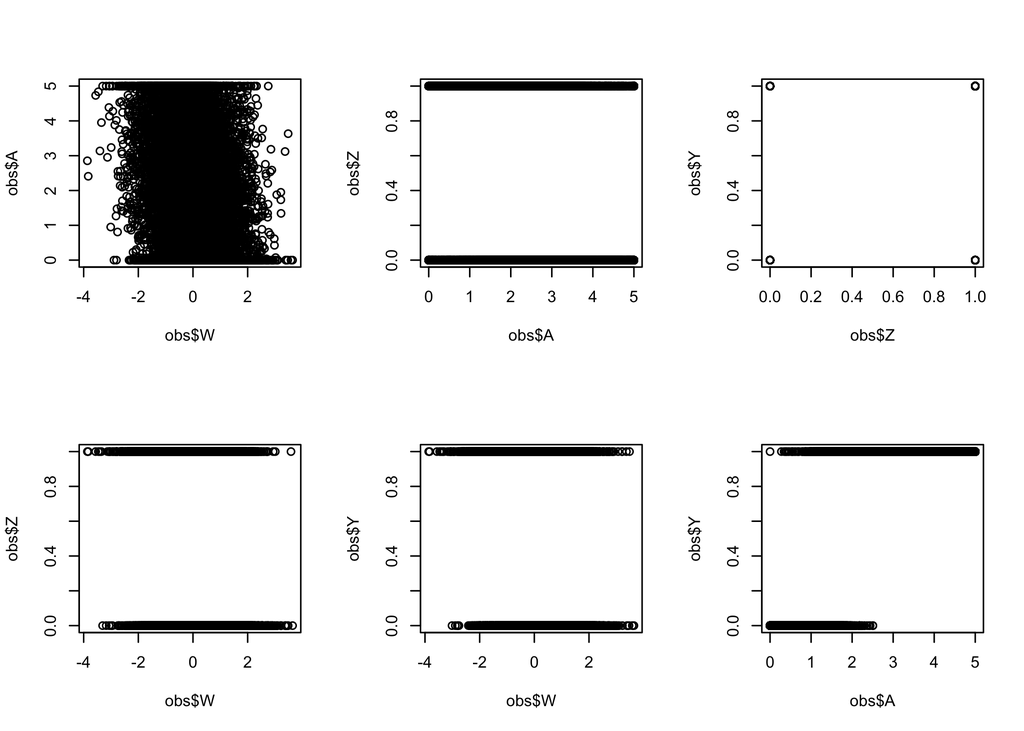

## n = 200

### results

```
## $`ATE_z=1`
##      targ_par   psi0 mean_under mean_init  bias_u  bias_i   sd_u   sd_i  mse_u
## 1  ATE(0.5,0) 0.0129     0.0196    0.0218  0.0067  0.0090 0.0429 0.0129 0.0019
## 2    ATE(1,0) 0.1276     0.1384    0.1486  0.0108  0.0210 0.1217 0.0638 0.0149
## 3  ATE(1.5,0) 0.6191     0.5987    0.6042 -0.0204 -0.0149 0.2088 0.1135 0.0440
## 4    ATE(2,0) 0.9511     0.8993    0.9141 -0.0518 -0.0370 0.1647 0.0457 0.0298
## 5  ATE(2.5,0) 0.9943     0.9558    0.9772 -0.0385 -0.0170 0.1477 0.0156 0.0233
## 6    ATE(3,0) 0.9981     0.9654    0.9883 -0.0327 -0.0098 0.1456 0.0097 0.0223
## 7  ATE(3.5,0) 0.9985     0.9679    0.9906 -0.0305 -0.0079 0.1453 0.0088 0.0220
## 8    ATE(4,0) 0.9985     0.9687    0.9911 -0.0298 -0.0074 0.1453 0.0085 0.0220
## 9  ATE(4.5,0) 0.9985     0.9689    0.9913 -0.0296 -0.0072 0.1455 0.0084 0.0220
## 10   ATE(5,0) 0.9985     0.9689    0.9914 -0.0297 -0.0071 0.1458 0.0083 0.0221
##     mse_i cov_rate_u cov_rate_i
## 1  0.0002      0.927      0.896
## 2  0.0045      0.947      0.947
```

[output cut: 37 more lines]

### View QQ plot of estimates

Checkout estimates of ATE(0.5,0) and ATE(5,0)

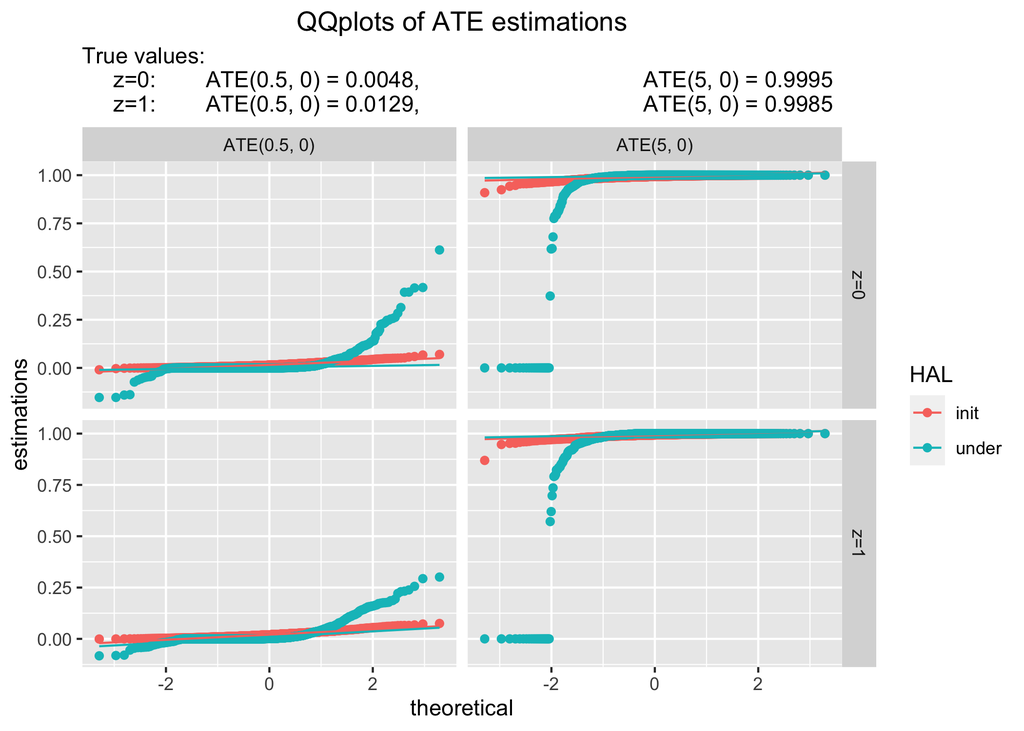

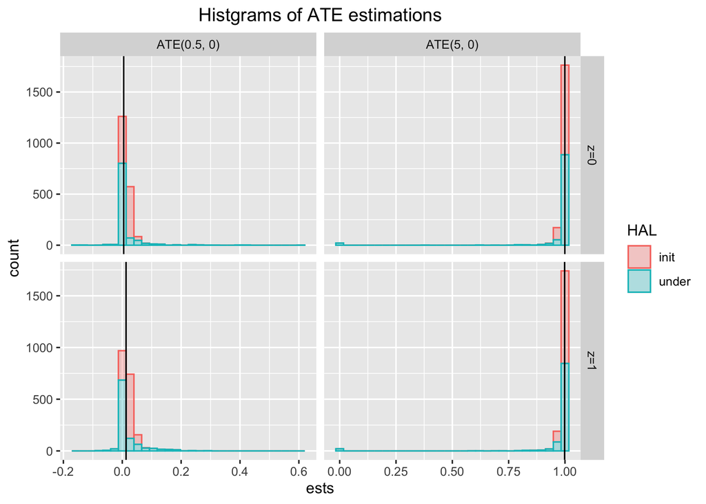

## n = 500

### results

```
## $`ATE_z=1`
##      targ_par   psi0 mean_under mean_init  bias_u  bias_i   sd_u   sd_i  mse_u
## 1  ATE(0.5,0) 0.0129     0.0205    0.0169  0.0076  0.0040 0.0386 0.0084 0.0015
## 2    ATE(1,0) 0.1276     0.1322    0.1330  0.0046  0.0054 0.0911 0.0420 0.0083
## 3  ATE(1.5,0) 0.6191     0.5938    0.6122 -0.0253 -0.0069 0.1676 0.0782 0.0287
## 4    ATE(2,0) 0.9511     0.9024    0.9322 -0.0487 -0.0189 0.1835 0.0278 0.0360
## 5  ATE(2.5,0) 0.9943     0.9534    0.9860 -0.0409 -0.0083 0.1808 0.0077 0.0344
## 6    ATE(3,0) 0.9981     0.9584    0.9932 -0.0398 -0.0049 0.1811 0.0045 0.0344
## 7  ATE(3.5,0) 0.9985     0.9577    0.9943 -0.0408 -0.0042 0.1818 0.0041 0.0347
## 8    ATE(4,0) 0.9985     0.9557    0.9945 -0.0428 -0.0040 0.1827 0.0040 0.0352
## 9  ATE(4.5,0) 0.9985     0.9534    0.9946 -0.0451 -0.0039 0.1836 0.0039 0.0358
## 10   ATE(5,0) 0.9985     0.9507    0.9946 -0.0478 -0.0039 0.1849 0.0040 0.0365
##     mse_i cov_rate_u cov_rate_i
## 1  0.0001      0.937      0.915
## 2  0.0018      0.958      0.959
```

[output cut: 37 more lines]

### View QQ plot of estimates

Checkout estimates of ATE(0.5,0) and ATE(5,0)

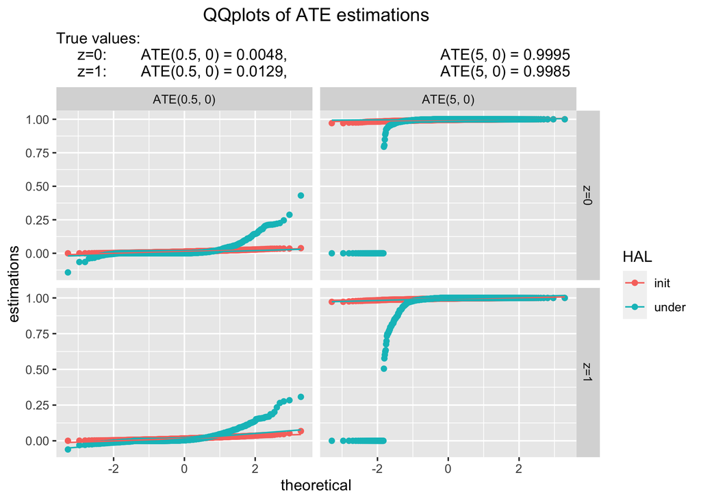

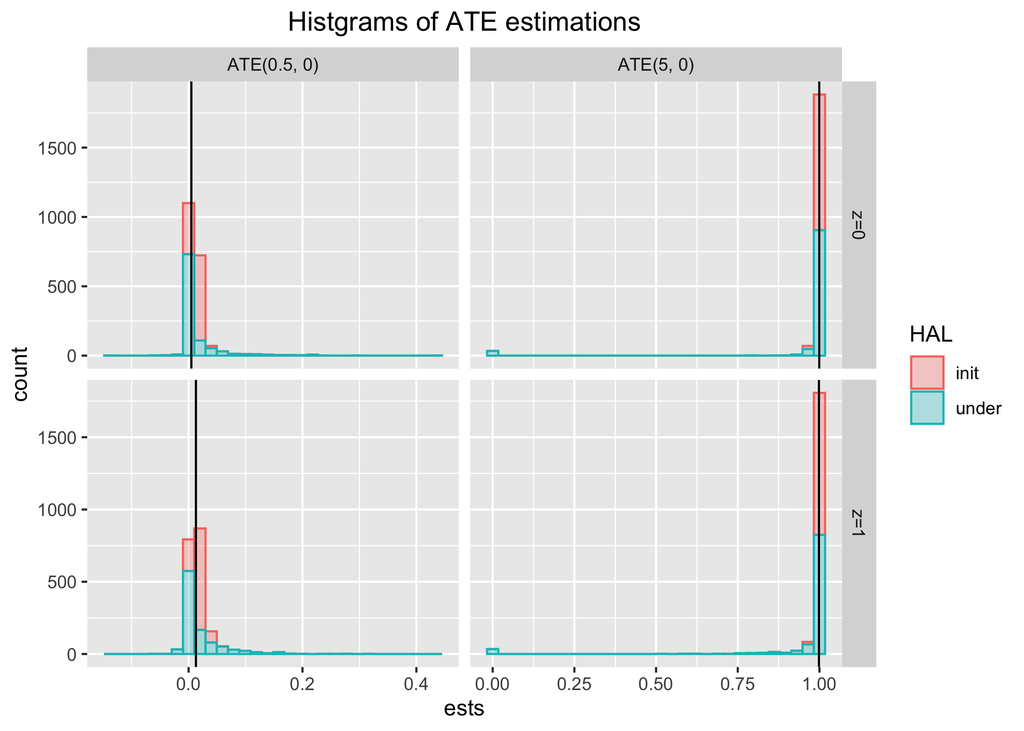

## n = 1000

### results

```
## $`ATE_z=1`
##      targ_par   psi0 mean_under mean_init  bias_u  bias_i   sd_u   sd_i  mse_u
## 1  ATE(0.5,0) 0.0129     0.0165    0.0147  0.0036  0.0018 0.0235 0.0061 0.0006
## 2    ATE(1,0) 0.1276     0.1305    0.1286  0.0029  0.0011 0.0667 0.0304 0.0045
## 3  ATE(1.5,0) 0.6191     0.6104    0.6185 -0.0087 -0.0006 0.1226 0.0573 0.0151
## 4    ATE(2,0) 0.9511     0.9268    0.9405 -0.0243 -0.0106 0.1390 0.0201 0.0199
## 5  ATE(2.5,0) 0.9943     0.9718    0.9897 -0.0225 -0.0046 0.1369 0.0050 0.0192
## 6    ATE(3,0) 0.9981     0.9752    0.9953 -0.0229 -0.0028 0.1371 0.0030 0.0193
## 7  ATE(3.5,0) 0.9985     0.9753    0.9960 -0.0232 -0.0025 0.1370 0.0028 0.0193
## 8    ATE(4,0) 0.9985     0.9740    0.9961 -0.0245 -0.0024 0.1376 0.0028 0.0195
## 9  ATE(4.5,0) 0.9985     0.9727    0.9961 -0.0259 -0.0024 0.1384 0.0028 0.0198
## 10   ATE(5,0) 0.9985     0.9707    0.9961 -0.0278 -0.0024 0.1394 0.0028 0.0202
##     mse_i cov_rate_u cov_rate_i
## 1  0.0000      0.943      0.934
## 2  0.0009      0.955      0.956
```

[output cut: 37 more lines]

### View QQ plot of estimates

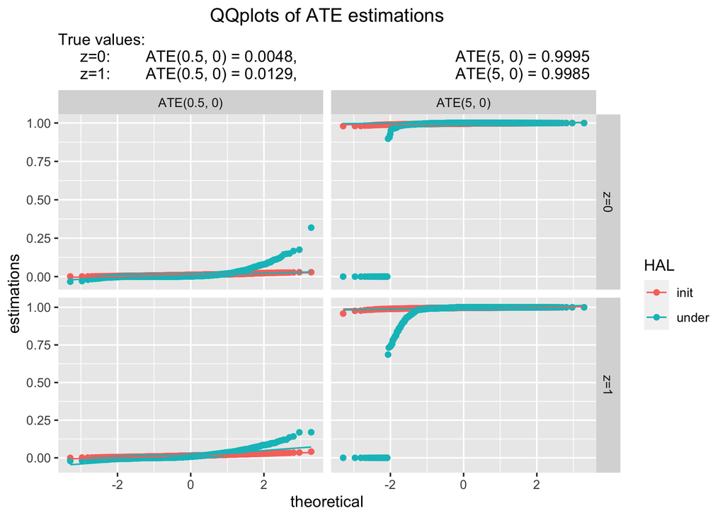

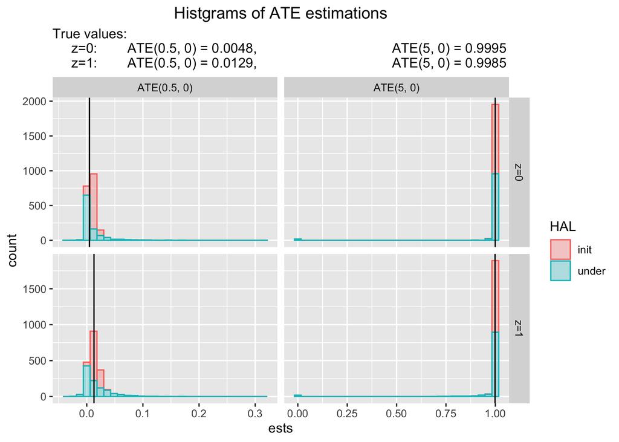

# Simulation #1_1

[Same as Simulation #1, but with posibility violation as the variance of U_A decreased]  
Data structure: $O = (W, A, Z, Y)$

- U - exogenous variables
- W - baseline covariate that is a measure of body condition
- A - treatment level based on W, continuous between 0 and 5
- Z - intermediate curve based on W and A
- Y - outcome, indicator of an event ?

Underlying data generating process, $P_{U,X}$

- Exogenous variables:
  - $U_A \sim Normal(\mu=0, \sigma^2 = 1^2)$
  - $U_A \sim Normal(\mu=0, \sigma^2 = 1^2)$
  - $U_Z \sim Uniform(min = 0, max = 1)$
  - $U_Y \sim Uniform(min = 0, max = 1)$
- Structural equations F and endogenous variables:
  - $W = U_W$
  - $A = bound(2 - 0.5W + U_A, min=0, max=5)$
  - $Z = \mathbf{I}[U_Z < expit(2-W-A)]$
  - $Y = \mathbf{I}[U_Y < expit(W + 5*A + Z - 0.5 * W * A - 8)]$

```
##        W                   A               Z                Y
##  Min.   :-3.914706   Min.   :0.000   Min.   :0.0000   Min.   :0.0000
##  1st Qu.:-0.662482   1st Qu.:1.236   1st Qu.:0.0000   1st Qu.:0.0000
##  Median : 0.006353   Median :2.002   Median :0.0000   Median :1.0000
##  Mean   : 0.004302   Mean   :2.016   Mean   :0.4987   Mean   :0.6733
##  3rd Qu.: 0.677346   3rd Qu.:2.758   3rd Qu.:1.0000   3rd Qu.:1.0000
##  Max.   : 4.907409   Max.   :5.000   Max.   :1.0000   Max.   :1.0000
```

```
## Summary of A given W < -1:
```

```
##    Min. 1st Qu.  Median    Mean 3rd Qu.    Max.
##   0.000   2.125   2.806   2.801   3.490   5.000
```

```
## Summary of A given -1 < W <= 0:
```

```
##    Min. 1st Qu.  Median    Mean 3rd Qu.    Max.
##   0.000   1.552   2.239   2.231   2.905   5.000
```

```
## Summary of A given 0 < W <= 1:
```

```
##    Min. 1st Qu.  Median    Mean 3rd Qu.    Max.
##   0.000   1.092   1.794   1.792   2.469   5.000
```

```
## Summary of A given 1 < W:
```

```
##    Min. 1st Qu.  Median    Mean 3rd Qu.    Max.
##  0.0000  0.5028  1.1851  1.2752  1.9053  4.3350
```

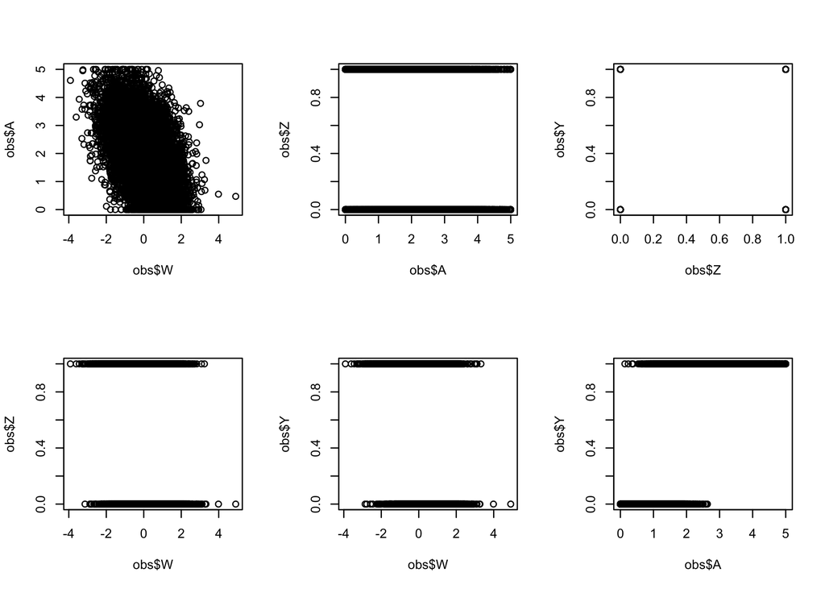

## n = 200

### results

```
## $`ATE_z=1`
##      targ_par   psi0 mean_under mean_init  bias_u  bias_i   sd_u   sd_i
## 1  ATE(0.5,0) 0.0128     0.0140    0.0285  0.0012  0.0157 0.0428 0.0155
## 2    ATE(1,0) 0.1273     0.1255    0.1582 -0.0018  0.0310 0.1102 0.0546
## 3  ATE(1.5,0) 0.6195     0.5943    0.5974 -0.0252 -0.0221 0.1735 0.0887
## 4    ATE(2,0) 0.9511     0.8995    0.9136 -0.0516 -0.0374 0.1459 0.0377
## 5  ATE(2.5,0) 0.9943     0.9529    0.9730 -0.0414 -0.0213 0.1326 0.0196
## 6    ATE(3,0) 0.9981     0.9615    0.9825 -0.0366 -0.0156 0.1295 0.0172
## 7  ATE(3.5,0) 0.9985     0.9634    0.9843 -0.0350 -0.0141 0.1290 0.0167
## 8    ATE(4,0) 0.9985     0.9641    0.9847 -0.0344 -0.0137 0.1291 0.0166
## 9  ATE(4.5,0) 0.9985     0.9643    0.9849 -0.0342 -0.0136 0.1292 0.0165
## 10   ATE(5,0) 0.9985     0.9644    0.9849 -0.0341 -0.0136 0.1292 0.0165
##    cov_rate_u cov_rate_i  mse_u  mse_i
## 1       0.941      0.825 0.0018 0.0005
## 2       0.948      0.906 0.0121 0.0039
```

[output cut: 37 more lines]

## n = 500

### results

```
## $`ATE_z=1`
##      targ_par   psi0 mean_under mean_init  bias_u  bias_i   sd_u   sd_i
## 1  ATE(0.5,0) 0.0128     0.0137    0.0223  0.0009  0.0095 0.0227 0.0099
## 2    ATE(1,0) 0.1273     0.1241    0.1430 -0.0031  0.0158 0.0710 0.0360
## 3  ATE(1.5,0) 0.6195     0.6070    0.6064 -0.0125 -0.0131 0.1311 0.0605
## 4    ATE(2,0) 0.9511     0.9266    0.9315 -0.0245 -0.0196 0.1164 0.0220
## 5  ATE(2.5,0) 0.9943     0.9725    0.9819 -0.0218 -0.0124 0.1108 0.0106
## 6    ATE(3,0) 0.9981     0.9772    0.9883 -0.0209 -0.0098 0.1112 0.0097
## 7  ATE(3.5,0) 0.9985     0.9769    0.9892 -0.0215 -0.0092 0.1124 0.0095
## 8    ATE(4,0) 0.9985     0.9762    0.9894 -0.0223 -0.0091 0.1140 0.0095
## 9  ATE(4.5,0) 0.9985     0.9756    0.9895 -0.0229 -0.0090 0.1150 0.0095
## 10   ATE(5,0) 0.9985     0.9750    0.9895 -0.0235 -0.0090 0.1157 0.0096
##    cov_rate_u cov_rate_i  mse_u  mse_i
## 1       0.936      0.837 0.0005 0.0002
## 2       0.957      0.931 0.0050 0.0015
```

[output cut: 37 more lines]

## n = 1000

### results

```
## $`ATE_z=1`
##      targ_par   psi0 mean_under mean_init  bias_u  bias_i   sd_u   sd_i
## 1  ATE(0.5,0) 0.0128     0.0106    0.0189 -0.0022  0.0061 0.0152 0.0073
## 2    ATE(1,0) 0.1273     0.1248    0.1378 -0.0024  0.0106 0.0501 0.0255
## 3  ATE(1.5,0) 0.6195     0.6196    0.6125  0.0001 -0.0070 0.0877 0.0449
## 4    ATE(2,0) 0.9511     0.9403    0.9398 -0.0107 -0.0112 0.0674 0.0158
## 5  ATE(2.5,0) 0.9943     0.9852    0.9873 -0.0091 -0.0070 0.0577 0.0063
## 6    ATE(3,0) 0.9981     0.9886    0.9924 -0.0095 -0.0057 0.0578 0.0055
## 7  ATE(3.5,0) 0.9985     0.9878    0.9930 -0.0107 -0.0054 0.0594 0.0054
## 8    ATE(4,0) 0.9985     0.9864    0.9931 -0.0121 -0.0053 0.0627 0.0054
## 9  ATE(4.5,0) 0.9985     0.9851    0.9932 -0.0134 -0.0053 0.0654 0.0054
## 10   ATE(5,0) 0.9985     0.9838    0.9932 -0.0147 -0.0053 0.0679 0.0054
##    cov_rate_u cov_rate_i  mse_u  mse_i
## 1       0.959      0.863 0.0002 0.0001
## 2       0.943      0.928 0.0025 0.0008
```

[output cut: 37 more lines]

# Simulation #1_2

[Same as Simulation #1, but with a 3-way interaction]  
Data structure: $O = (W, A, Z, Y)$

- U - exogenous variables
- W - baseline covariate that is a measure of body condition
- A - treatment level based on W, continuous between 0 and 5
- Z - intermediate curve based on W and A
- Y - outcome, indicator of an event ?

Underlying data generating process, $P_{U,X}$

- Exogenous variables:
  - $U_A \sim Normal(\mu=0, \sigma^2 = 1^2)$
  - $U_A \sim Normal(\mu=0, \sigma^2 = 2^2)$
  - $U_Z \sim Uniform(min = 0, max = 1)$
  - $U_Y \sim Uniform(min = 0, max = 1)$
- Structural equations F and endogenous variables:
  - $W = U_W$
  - $A = bound(2 - 0.5W + U_A, min=0, max=5)$
  - $Z = \mathbf{I}[U_Z < expit(2-W-A)]$
  - $Y = \mathbf{I}[U_Y < expit(W + 5*A + Z - 0.5 * W * A + 0.3 * W * A * (Z+1) - 8)]$

```
##        W                  A               Z                Y
##  Min.   :-3.60460   Min.   :0.000   Min.   :0.0000   Min.   :0.0000
##  1st Qu.:-0.66868   1st Qu.:0.618   1st Qu.:0.0000   1st Qu.:0.0000
##  Median : 0.02012   Median :1.998   Median :0.0000   Median :1.0000
##  Mean   : 0.00719   Mean   :2.099   Mean   :0.4895   Mean   :0.5985
##  3rd Qu.: 0.67983   3rd Qu.:3.333   3rd Qu.:1.0000   3rd Qu.:1.0000
##  Max.   : 3.98610   Max.   :5.000   Max.   :1.0000   Max.   :1.0000
```

```
## Summary of A given W < -1:
```

```
##    Min. 1st Qu.  Median    Mean 3rd Qu.    Max.
##   0.000   1.379   2.668   2.651   3.959   5.000
```

```
## Summary of A given -1 < W <= 0:
```

```
##    Min. 1st Qu.  Median    Mean 3rd Qu.    Max.
##  0.0000  0.9207  2.3095  2.3062  3.5964  5.0000
```

```
## Summary of A given 0 < W <= 1:
```

```
##    Min. 1st Qu.  Median    Mean 3rd Qu.    Max.
##   0.000   0.437   1.780   1.925   3.102   5.000
```

```
## Summary of A given 1 < W:
```

```
##    Min. 1st Qu.  Median    Mean 3rd Qu.    Max.
##   0.000   0.000   1.221   1.500   2.546   5.000
```

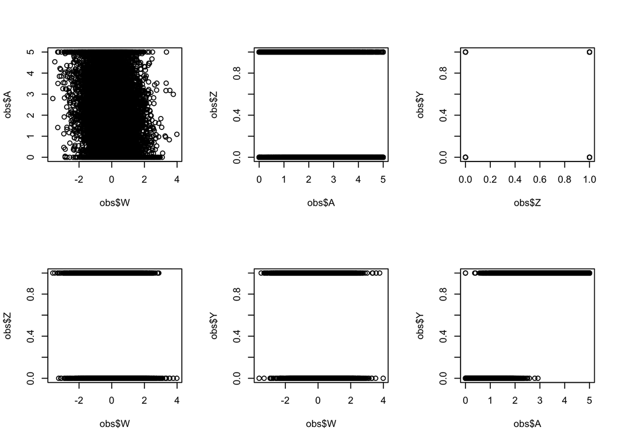

## n = 200

### results

```
## $`ATE_z=1`
##      targ_par   psi0 mean_under mean_init  bias_u  bias_i   sd_u   sd_i
## 1  ATE(0.5,0) 0.0168     0.0231    0.0203  0.0063  0.0035 0.0489 0.0157
## 2    ATE(1,0) 0.1603     0.1611    0.1553  0.0008 -0.0050 0.1307 0.0720
## 3  ATE(1.5,0) 0.5959     0.5706    0.5929 -0.0253 -0.0030 0.1933 0.1036
## 4    ATE(2,0) 0.9193     0.8733    0.8960 -0.0460 -0.0233 0.1712 0.0444
## 5  ATE(2.5,0) 0.9899     0.9508    0.9712 -0.0391 -0.0187 0.1584 0.0161
## 6    ATE(3,0) 0.9977     0.9618    0.9875 -0.0359 -0.0102 0.1583 0.0087
## 7  ATE(3.5,0) 0.9984     0.9639    0.9916 -0.0345 -0.0068 0.1586 0.0070
## 8    ATE(4,0) 0.9985     0.9644    0.9929 -0.0341 -0.0056 0.1588 0.0066
## 9  ATE(4.5,0) 0.9985     0.9646    0.9933 -0.0339 -0.0052 0.1589 0.0064
## 10   ATE(5,0) 0.9985     0.9645    0.9935 -0.0340 -0.0050 0.1591 0.0064
##    cov_rate_u cov_rate_i  mse_u  mse_i
## 1       0.935      0.954 0.0024 0.0003
## 2       0.960      0.956 0.0171 0.0052
```

[output cut: 37 more lines]

## n = 500

### results

```
## $`ATE_z=1`
##      targ_par   psi0 mean_under mean_init  bias_u  bias_i   sd_u   sd_i
## 1  ATE(0.5,0) 0.0168     0.0220    0.0166  0.0052 -0.0002 0.0348 0.0091
## 2    ATE(1,0) 0.1603     0.1528    0.1469 -0.0075 -0.0134 0.0953 0.0472
## 3  ATE(1.5,0) 0.5959     0.5713    0.6010 -0.0247  0.0050 0.1512 0.0672
## 4    ATE(2,0) 0.9193     0.8801    0.9094 -0.0392 -0.0099 0.1688 0.0278
## 5  ATE(2.5,0) 0.9899     0.9533    0.9792 -0.0366 -0.0107 0.1682 0.0090
## 6    ATE(3,0) 0.9977     0.9636    0.9919 -0.0341 -0.0058 0.1676 0.0046
## 7  ATE(3.5,0) 0.9984     0.9643    0.9945 -0.0341 -0.0039 0.1679 0.0038
## 8    ATE(4,0) 0.9985     0.9632    0.9952 -0.0353 -0.0033 0.1685 0.0036
## 9  ATE(4.5,0) 0.9985     0.9609    0.9954 -0.0376 -0.0031 0.1695 0.0036
## 10   ATE(5,0) 0.9985     0.9579    0.9954 -0.0406 -0.0031 0.1717 0.0035
##    cov_rate_u cov_rate_i  mse_u  mse_i
## 1       0.930      0.960 0.0012 0.0001
## 2       0.963      0.951 0.0091 0.0024
```

[output cut: 37 more lines]

## n = 1000

### results

```
## $`ATE_z=1`
##      targ_par   psi0 mean_under mean_init  bias_u  bias_i   sd_u   sd_i
## 1  ATE(0.5,0) 0.0168     0.0212    0.0157  0.0044 -0.0011 0.0264 0.0072
## 2    ATE(1,0) 0.1603     0.1580    0.1488 -0.0023 -0.0115 0.0681 0.0354
## 3  ATE(1.5,0) 0.5959     0.5835    0.6014 -0.0125  0.0055 0.1067 0.0456
## 4    ATE(2,0) 0.9193     0.9004    0.9131 -0.0189 -0.0062 0.1220 0.0204
## 5  ATE(2.5,0) 0.9899     0.9732    0.9825 -0.0167 -0.0074 0.1215 0.0063
## 6    ATE(3,0) 0.9977     0.9811    0.9939 -0.0166 -0.0038 0.1214 0.0030
## 7  ATE(3.5,0) 0.9984     0.9814    0.9960 -0.0171 -0.0025 0.1216 0.0025
## 8    ATE(4,0) 0.9985     0.9805    0.9964 -0.0180 -0.0021 0.1219 0.0024
## 9  ATE(4.5,0) 0.9985     0.9787    0.9965 -0.0198 -0.0020 0.1226 0.0024
## 10   ATE(5,0) 0.9985     0.9766    0.9965 -0.0219 -0.0020 0.1235 0.0024
##    cov_rate_u cov_rate_i  mse_u  mse_i
## 1       0.936      0.971 0.0007 0.0001
## 2       0.950      0.941 0.0046 0.0014
```

[output cut: 37 more lines]

# Simulation #1_3

[Same as Simulation #1, but with a 3-way interaction and positivity violations]

Data structure: $O = (W, A, Z, Y)$

- U - exogenous variables
- W - baseline covariate that is a measure of body condition
- A - treatment level based on W, continuous between 0 and 5
- Z - intermediate curve based on W and A
- Y - outcome, indicator of an event ?

Underlying data generating process, $P_{U,X}$

- Exogenous variables:
  - $U_A \sim Normal(\mu=0, \sigma^2 = 1^2)$
  - $U_A \sim Normal(\mu=0, \sigma^2 = 1^2)$
  - $U_Z \sim Uniform(min = 0, max = 1)$
  - $U_Y \sim Uniform(min = 0, max = 1)$
- Structural equations F and endogenous variables:
  - $W = U_W$
  - $A = bound(2 - 0.5W + U_A, min=0, max=5)$
  - $Z = \mathbf{I}[U_Z < expit(2-W-A)]$
  - $Y = \mathbf{I}[U_Y < expit(W + 5*A + Z - 0.5 * W * A + 0.3 * W * A * (Z+1) - 8)]$

```
##        W                   A               Z               Y
##  Min.   :-3.564065   Min.   :0.000   Min.   :0.000   Min.   :0.0000
##  1st Qu.:-0.683796   1st Qu.:1.275   1st Qu.:0.000   1st Qu.:0.0000
##  Median :-0.004318   Median :2.021   Median :0.000   Median :1.0000
##  Mean   :-0.004664   Mean   :2.044   Mean   :0.494   Mean   :0.6823
##  3rd Qu.: 0.674528   3rd Qu.:2.788   3rd Qu.:1.000   3rd Qu.:1.0000
##  Max.   : 3.386300   Max.   :5.000   Max.   :1.000   Max.   :1.0000
```

```
## Summary of A given W < -1:
```

```
##    Min. 1st Qu.  Median    Mean 3rd Qu.    Max.
##   0.000   2.053   2.757   2.773   3.493   5.000
```

```
## Summary of A given -1 < W <= 0:
```

```
##    Min. 1st Qu.  Median    Mean 3rd Qu.    Max.
##   0.000   1.562   2.282   2.275   2.958   5.000
```

```
## Summary of A given 0 < W <= 1:
```

```
##    Min. 1st Qu.  Median    Mean 3rd Qu.    Max.
##   0.000   1.091   1.787   1.804   2.482   5.000
```

```
## Summary of A given 1 < W:
```

```
##    Min. 1st Qu.  Median    Mean 3rd Qu.    Max.
##  0.0000  0.6216  1.2635  1.3159  1.9208  4.6282
```

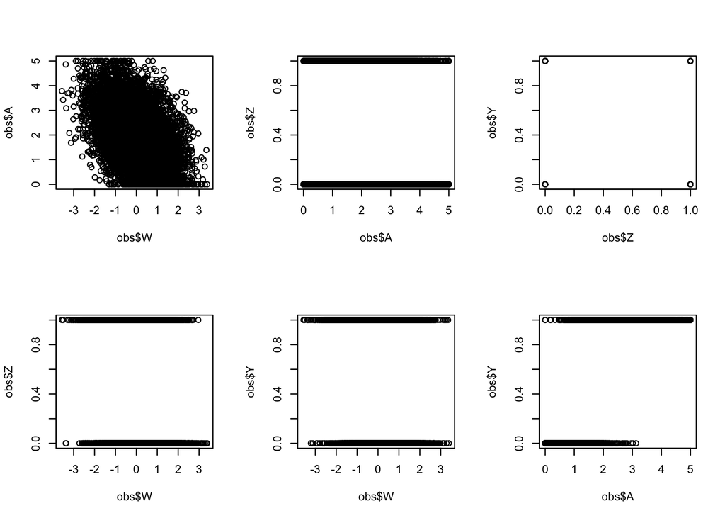

## n = 200

### results

```
## $`ATE_z=1`
##      targ_par   psi0 mean_under mean_init  bias_u  bias_i   sd_u   sd_i
## 1  ATE(0.5,0) 0.0169     0.0166    0.0258 -0.0004  0.0089 0.0410 0.0149
## 2    ATE(1,0) 0.1607     0.1532    0.1667 -0.0075  0.0060 0.1115 0.0567
## 3  ATE(1.5,0) 0.5961     0.5797    0.5965 -0.0164  0.0004 0.1493 0.0791
## 4    ATE(2,0) 0.9194     0.8873    0.8988 -0.0321 -0.0206 0.1285 0.0349
## 5  ATE(2.5,0) 0.9899     0.9600    0.9702 -0.0299 -0.0197 0.1173 0.0167
## 6    ATE(3,0) 0.9977     0.9707    0.9846 -0.0270 -0.0132 0.1144 0.0133
## 7  ATE(3.5,0) 0.9985     0.9725    0.9879 -0.0260 -0.0106 0.1142 0.0126
## 8    ATE(4,0) 0.9985     0.9727    0.9888 -0.0259 -0.0098 0.1143 0.0125
## 9  ATE(4.5,0) 0.9985     0.9726    0.9891 -0.0260 -0.0095 0.1146 0.0124
## 10   ATE(5,0) 0.9985     0.9724    0.9892 -0.0261 -0.0094 0.1148 0.0124
##    cov_rate_u cov_rate_i  mse_u  mse_i
## 1       0.946      0.897 0.0017 0.0003
## 2       0.951      0.956 0.0125 0.0033
```

[output cut: 37 more lines]

## n = 500

### results

```
## $`ATE_z=1`
##      targ_par   psi0 mean_under mean_init  bias_u  bias_i   sd_u   sd_i
## 1  ATE(0.5,0) 0.0169     0.0156    0.0212 -0.0014  0.0042 0.0260 0.0100
## 2    ATE(1,0) 0.1607     0.1548    0.1589 -0.0059 -0.0018 0.0746 0.0370
## 3  ATE(1.5,0) 0.5961     0.5881    0.5990 -0.0080  0.0029 0.1119 0.0520
## 4    ATE(2,0) 0.9194     0.8984    0.9098 -0.0210 -0.0096 0.1011 0.0218
## 5  ATE(2.5,0) 0.9899     0.9746    0.9777 -0.0153 -0.0122 0.0913 0.0093
## 6    ATE(3,0) 0.9977     0.9841    0.9894 -0.0136 -0.0084 0.0907 0.0076
## 7  ATE(3.5,0) 0.9985     0.9846    0.9916 -0.0139 -0.0068 0.0913 0.0074
## 8    ATE(4,0) 0.9985     0.9843    0.9922 -0.0142 -0.0064 0.0917 0.0073
## 9  ATE(4.5,0) 0.9985     0.9839    0.9923 -0.0147 -0.0062 0.0922 0.0073
## 10   ATE(5,0) 0.9985     0.9835    0.9924 -0.0151 -0.0062 0.0927 0.0073
##    cov_rate_u cov_rate_i  mse_u  mse_i
## 1       0.947      0.923 0.0007 0.0001
## 2       0.942      0.948 0.0056 0.0014
```

[output cut: 37 more lines]

## n = 1000

### results

```
## $`ATE_z=1`
##      targ_par   psi0 mean_under mean_init  bias_u  bias_i   sd_u   sd_i
## 1  ATE(0.5,0) 0.0169     0.0131    0.0196 -0.0039  0.0027 0.0151 0.0073
## 2    ATE(1,0) 0.1607     0.1573    0.1601 -0.0034 -0.0006 0.0515 0.0279
## 3  ATE(1.5,0) 0.5961     0.5925    0.6018 -0.0036  0.0057 0.0890 0.0372
## 4    ATE(2,0) 0.9194     0.9052    0.9150 -0.0142 -0.0044 0.0911 0.0159
## 5  ATE(2.5,0) 0.9899     0.9783    0.9820 -0.0117 -0.0079 0.0893 0.0062
## 6    ATE(3,0) 0.9977     0.9866    0.9923 -0.0111 -0.0054 0.0893 0.0047
## 7  ATE(3.5,0) 0.9985     0.9859    0.9941 -0.0125 -0.0044 0.0902 0.0045
## 8    ATE(4,0) 0.9985     0.9844    0.9944 -0.0141 -0.0041 0.0924 0.0044
## 9  ATE(4.5,0) 0.9985     0.9829    0.9945 -0.0156 -0.0040 0.0952 0.0044
## 10   ATE(5,0) 0.9985     0.9815    0.9945 -0.0170 -0.0040 0.0979 0.0044
##    cov_rate_u cov_rate_i  mse_u  mse_i
## 1       0.953      0.936 0.0002 0.0001
## 2       0.953      0.948 0.0027 0.0008
```

[output cut: 37 more lines]

# Simulation #2

Data structure: $O = (W, A, Z, Y)$

- U - exogenous variables
- W - baseline covariate that is a measure of body condition
- A - treatment level based on W, continuous between 0 and 10
- Z - intermediate curve based on W and A
- Y - outcome, indicator of an event ?

Underlying data generating process, $P_{U,X}$

- Exogenous variables:
  - $U_A \sim Normal(\mu=0, \sigma^2 = 1^2)$
  - $U_A \sim Normal(\mu=0, \sigma^2 = 4^2)$
  - $U_Z \sim Uniform(min = 0, max = 1)$
  - $U_Y \sim Uniform(min = 0, max = 1)$
- Structural equations F and endogenous variables:
  - $W = U_W$
  - $A = bound(5+ 2W + U_A, min=0, max=10)$
  - $Z = \mathbf{I}[U_Z < expit(-2W+A-4)]$
  - $Y = \mathbf{I}[U_Y < expit(W + A + Z - 0.5 * W * A + 0.1*W*A*Z -4)]$

```
##        W                   A                Z                Y
##  Min.   :-3.914706   Min.   : 0.000   Min.   :0.0000   Min.   :0.0000
##  1st Qu.:-0.663495   1st Qu.: 1.954   1st Qu.:0.0000   1st Qu.:0.0000
##  Median : 0.004170   Median : 5.028   Median :1.0000   Median :1.0000
##  Mean   : 0.003428   Mean   : 5.001   Mean   :0.6017   Mean   :0.5854
##  3rd Qu.: 0.676302   3rd Qu.: 7.978   3rd Qu.:1.0000   3rd Qu.:1.0000
##  Max.   : 4.907409   Max.   :10.000   Max.   :1.0000   Max.   :1.0000
```

```
## Summary of A given W < -2:
```

```
##      Min.   1st Qu.    Median      Mean   3rd Qu.      Max.
##  0.000000  0.000000  0.005045  1.643645  2.878046 10.000000
```

```
## Summary of A given -2 <= W < -1:
```

```
##    Min. 1st Qu.  Median    Mean 3rd Qu.    Max.
##   0.000   0.000   2.510   3.045   5.044  10.000
```

```
## Summary of A given -1 < W <= 0:
```

```
##    Min. 1st Qu.  Median    Mean 3rd Qu.    Max.
##   0.000   1.358   4.138   4.269   6.802  10.000
```

```
## Summary of A given 0 < W <= 1:
```

```
##    Min. 1st Qu.  Median    Mean 3rd Qu.    Max.
##   0.000   3.189   5.954   5.740   8.678  10.000
```

```
## Summary of A given 1 < W <= 2:
```

```
##    Min. 1st Qu.  Median    Mean 3rd Qu.    Max.
##   0.000   4.834   7.560   6.920  10.000  10.000
```

```
## Summary of A given 2 < W :
```

```
##    Min. 1st Qu.  Median    Mean 3rd Qu.    Max.
##   0.000   6.719   9.358   8.201  10.000  10.000
```

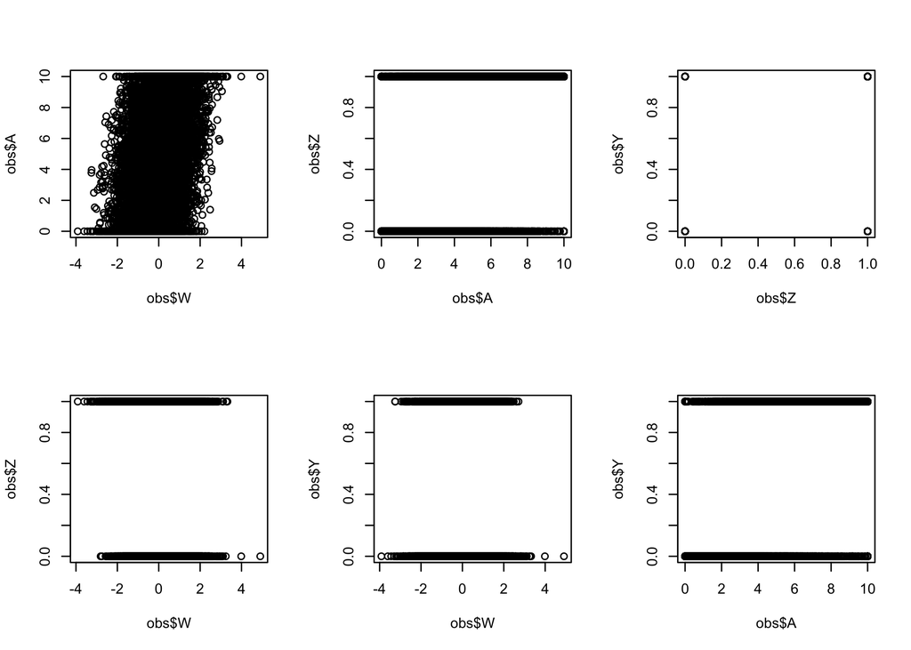

## n = 200

### results

```
## $`ATE_z=1`
##      targ_par   psi0 mean_under mean_init  bias_u  bias_i   sd_u   sd_i
## 1  ATE(0.5,0) 0.0255     0.0174    0.0166 -0.0081 -0.0089 0.0716 0.0145
## 2    ATE(1,0) 0.0639     0.0638    0.0476 -0.0001 -0.0162 0.1429 0.0358
## 3  ATE(1.5,0) 0.1205     0.1380    0.1010  0.0175 -0.0195 0.2015 0.0636
## 4    ATE(2,0) 0.2015     0.2207    0.1819  0.0193 -0.0196 0.2433 0.0915
## 5  ATE(2.5,0) 0.3083     0.3125    0.2899  0.0042 -0.0184 0.2583 0.1124
## 6    ATE(3,0) 0.4307     0.4171    0.4170 -0.0136 -0.0137 0.2565 0.1206
## 7  ATE(3.5,0) 0.5487     0.5184    0.5453 -0.0304 -0.0034 0.2433 0.1155
## 8    ATE(4,0) 0.6472     0.6146    0.6575 -0.0326  0.0103 0.2339 0.1057
## 9  ATE(4.5,0) 0.7214     0.6888    0.7424 -0.0325  0.0211 0.2242 0.0943
## 10   ATE(5,0) 0.7751     0.7487    0.8030 -0.0264  0.0278 0.2150 0.0837
## 11 ATE(5.5,0) 0.8133     0.7869    0.8451 -0.0264  0.0319 0.2036 0.0749
## 12   ATE(6,0) 0.8401     0.8115    0.8737 -0.0286  0.0336 0.1941 0.0679
## 13 ATE(6.5,0) 0.8594     0.8292    0.8937 -0.0302  0.0343 0.1900 0.0631
```

[output cut: 77 more lines]

## n = 500

### results

```
## $`ATE_z=1`
##      targ_par   psi0 mean_under mean_init  bias_u  bias_i   sd_u   sd_i
## 1  ATE(0.5,0) 0.0255     0.0110    0.0156 -0.0145 -0.0099 0.0454 0.0093
## 2    ATE(1,0) 0.0639     0.0499    0.0469 -0.0140 -0.0170 0.1003 0.0250
## 3  ATE(1.5,0) 0.1205     0.1303    0.1038  0.0098 -0.0168 0.1681 0.0501
## 4    ATE(2,0) 0.2015     0.2141    0.1872  0.0126 -0.0142 0.1997 0.0720
## 5  ATE(2.5,0) 0.3083     0.3095    0.2979  0.0012 -0.0104 0.1985 0.0823
## 6    ATE(3,0) 0.4307     0.4258    0.4295 -0.0049 -0.0013 0.1978 0.0858
## 7  ATE(3.5,0) 0.5487     0.5347    0.5582 -0.0140  0.0095 0.1778 0.0793
## 8    ATE(4,0) 0.6472     0.6292    0.6694 -0.0180  0.0222 0.1695 0.0721
## 9  ATE(4.5,0) 0.7214     0.7015    0.7534 -0.0198  0.0320 0.1665 0.0640
## 10   ATE(5,0) 0.7751     0.7578    0.8129 -0.0173  0.0377 0.1611 0.0563
## 11 ATE(5.5,0) 0.8133     0.7945    0.8542 -0.0187  0.0410 0.1570 0.0506
## 12   ATE(6,0) 0.8401     0.8227    0.8823 -0.0174  0.0421 0.1533 0.0462
## 13 ATE(6.5,0) 0.8594     0.8397    0.9018 -0.0197  0.0424 0.1530 0.0440
```

[output cut: 77 more lines]

## n = 1000

### results

```
## $`ATE_z=1`
##      targ_par   psi0 mean_under mean_init  bias_u  bias_i   sd_u   sd_i
## 1  ATE(0.5,0) 0.0255     0.0115    0.0161 -0.0140 -0.0094 0.0371 0.0079
## 2    ATE(1,0) 0.0639     0.0488    0.0484 -0.0151 -0.0154 0.0792 0.0207
## 3  ATE(1.5,0) 0.1205     0.1258    0.1073  0.0053 -0.0132 0.1322 0.0415
## 4    ATE(2,0) 0.2015     0.2081    0.1929  0.0066 -0.0085 0.1587 0.0582
## 5  ATE(2.5,0) 0.3083     0.3016    0.3049 -0.0067 -0.0034 0.1540 0.0623
## 6    ATE(3,0) 0.4307     0.4206    0.4390 -0.0102  0.0083 0.1545 0.0628
## 7  ATE(3.5,0) 0.5487     0.5327    0.5668 -0.0160  0.0181 0.1412 0.0548
## 8    ATE(4,0) 0.6472     0.6289    0.6764 -0.0183  0.0292 0.1405 0.0500
## 9  ATE(4.5,0) 0.7214     0.7016    0.7581 -0.0198  0.0368 0.1416 0.0447
## 10   ATE(5,0) 0.7751     0.7522    0.8153 -0.0230  0.0401 0.1411 0.0386
## 11 ATE(5.5,0) 0.8133     0.7882    0.8557 -0.0251  0.0424 0.1371 0.0338
## 12   ATE(6,0) 0.8401     0.8178    0.8836 -0.0223  0.0435 0.1328 0.0290
## 13 ATE(6.5,0) 0.8594     0.8361    0.9031 -0.0233  0.0437 0.1326 0.0270
```

[output cut: 77 more lines]

# Simulation #3

Data structure: $O = (W, A, Z, Y)$

- U - exogenous variables
- W - baseline covariate that is a measure of body condition
- A - treatment level based on W, continuous between 0 and 10
- Z - intermediate curve based on W and A
- Y - outcome, indicator of an event ?

Underlying data generating process, $P_{U,X}$

- Exogenous variables:
  - $U_A \sim Normal(\mu=0, \sigma^2 = 1^2)$
  - $U_A \sim Normal(\mu=0, \sigma^2 = 1^2)$
  - $U_Z \sim Uniform(min = 0, max = 1)$
  - $U_Y \sim Uniform(min = 0, max = 1)$
- Structural equations F and endogenous variables:
  - $W = U_W$
  - $A = bound(5+ 2W + U_A, min=0, max=10)$
  - $Z = \mathbf{I}[U_Z < expit(-2W+A-4)]$
  - $Y = \mathbf{I}[U_Y < expit(W + A + Z - 0.5 * W * A + 0.1*W*A*Z -4)]$

```
##        W                   A                Z                Y
##  Min.   :-3.460778   Min.   : 0.000   Min.   :0.0000   Min.   :0.0000
##  1st Qu.:-0.662104   1st Qu.: 3.473   1st Qu.:0.0000   1st Qu.:0.0000
##  Median :-0.005003   Median : 4.988   Median :1.0000   Median :1.0000
##  Mean   :-0.004804   Mean   : 4.981   Mean   :0.6946   Mean   :0.6576
##  3rd Qu.: 0.658341   3rd Qu.: 6.496   3rd Qu.:1.0000   3rd Qu.:1.0000
##  Max.   : 4.818165   Max.   :10.000   Max.   :1.0000   Max.   :1.0000
```

```
## Summary of A given W < -1:
```

```
##    Min. 1st Qu.  Median    Mean 3rd Qu.    Max.
##   0.000   1.116   2.003   1.981   2.870   5.618
```

```
## Summary of A given -1 < W <= 0:
```

```
##    Min. 1st Qu.  Median    Mean 3rd Qu.    Max.
##   0.000   3.296   4.076   4.078   4.873   7.697
```

```
## Summary of A given 0 < W <= 1:
```

```
##    Min. 1st Qu.  Median    Mean 3rd Qu.    Max.
##   1.847   5.125   5.931   5.916   6.707  10.000
```

```
## Summary of A given 1 < W:
```

```
##    Min. 1st Qu.  Median    Mean 3rd Qu.    Max.
##   4.108   7.133   7.976   8.004   8.908  10.000
```

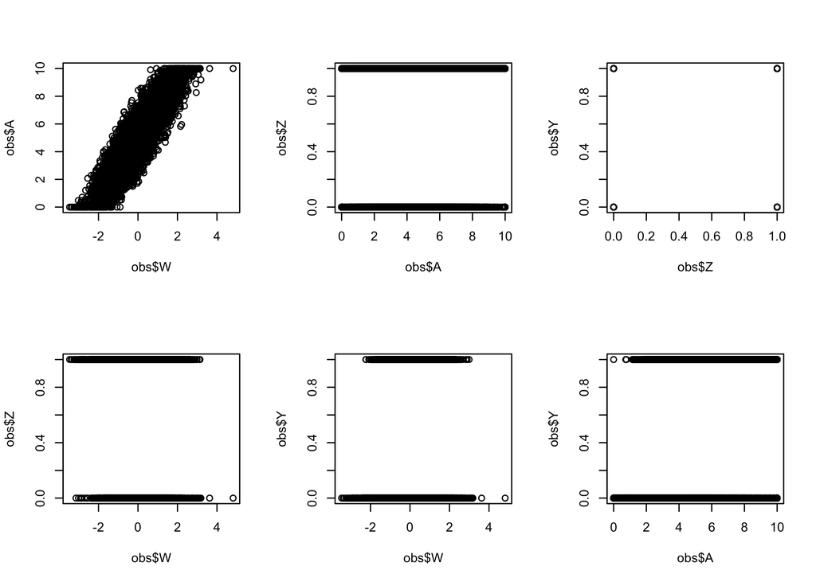

## n = 200

### results

```
## $`ATE_z=1`
##      targ_par   psi0 mean_under mean_init  bias_u  bias_i   sd_u   sd_i
## 1  ATE(0.5,0) 0.0257     0.0120    0.0196 -0.0136 -0.0060 0.0306 0.0116
## 2    ATE(1,0) 0.0637     0.0360    0.0520 -0.0277 -0.0117 0.0686 0.0271
## 3  ATE(1.5,0) 0.1205     0.0833    0.1028 -0.0372 -0.0178 0.1216 0.0478
## 4    ATE(2,0) 0.2015     0.1688    0.1787 -0.0327 -0.0228 0.1877 0.0714
## 5  ATE(2.5,0) 0.3083     0.2806    0.2815 -0.0277 -0.0268 0.2243 0.0905
## 6    ATE(3,0) 0.4308     0.4008    0.4036 -0.0300 -0.0272 0.2321 0.1010
## 7  ATE(3.5,0) 0.5489     0.5091    0.5262 -0.0398 -0.0227 0.2354 0.1020
## 8    ATE(4,0) 0.6473     0.6000    0.6323 -0.0473 -0.0150 0.2180 0.0912
## 9  ATE(4.5,0) 0.7216     0.6703    0.7160 -0.0512 -0.0056 0.2085 0.0793
## 10   ATE(5,0) 0.7752     0.7227    0.7779 -0.0525  0.0027 0.2015 0.0694
## 11 ATE(5.5,0) 0.8135     0.7607    0.8224 -0.0528  0.0089 0.1964 0.0616
## 12   ATE(6,0) 0.8402     0.7884    0.8540 -0.0518  0.0138 0.1933 0.0563
## 13 ATE(6.5,0) 0.8595     0.8079    0.8764 -0.0516  0.0169 0.1929 0.0528
```

[output cut: 77 more lines]

## n = 500

### results

```
## $`ATE_z=1`
##      targ_par   psi0 mean_under mean_init  bias_u  bias_i   sd_u   sd_i
## 1  ATE(0.5,0) 0.0257     0.0128    0.0165 -0.0129 -0.0092 0.0301 0.0071
## 2    ATE(1,0) 0.0637     0.0372    0.0442 -0.0265 -0.0195 0.0709 0.0174
## 3  ATE(1.5,0) 0.1205     0.0876    0.0906 -0.0329 -0.0299 0.1193 0.0317
## 4    ATE(2,0) 0.2015     0.1883    0.1651 -0.0132 -0.0364 0.1733 0.0504
## 5  ATE(2.5,0) 0.3083     0.3059    0.2721 -0.0024 -0.0362 0.2004 0.0672
## 6    ATE(3,0) 0.4308     0.4186    0.4065 -0.0122 -0.0244 0.2081 0.0774
## 7  ATE(3.5,0) 0.5489     0.5314    0.5422 -0.0175 -0.0067 0.2129 0.0796
## 8    ATE(4,0) 0.6473     0.6198    0.6525 -0.0275  0.0052 0.1936 0.0672
## 9  ATE(4.5,0) 0.7216     0.6892    0.7365 -0.0324  0.0150 0.1862 0.0547
## 10   ATE(5,0) 0.7752     0.7432    0.7977 -0.0321  0.0225 0.1812 0.0456
## 11 ATE(5.5,0) 0.8135     0.7801    0.8418 -0.0333  0.0283 0.1763 0.0378
## 12   ATE(6,0) 0.8402     0.8044    0.8727 -0.0358  0.0325 0.1750 0.0328
## 13 ATE(6.5,0) 0.8595     0.8230    0.8944 -0.0365  0.0349 0.1744 0.0298
```

[output cut: 77 more lines]

## n = 1000

### results

```
## $`ATE_z=1`
##      targ_par   psi0 mean_under mean_init  bias_u  bias_i   sd_u   sd_i
## 1  ATE(0.5,0) 0.0257     0.0135    0.0148 -0.0122 -0.0108 0.0231 0.0048
## 2    ATE(1,0) 0.0637     0.0382    0.0407 -0.0255 -0.0230 0.0529 0.0118
## 3  ATE(1.5,0) 0.1205     0.0882    0.0853 -0.0323 -0.0352 0.0890 0.0219
## 4    ATE(2,0) 0.2015     0.1916    0.1595 -0.0099 -0.0420 0.1332 0.0355
## 5  ATE(2.5,0) 0.3083     0.3141    0.2698  0.0058 -0.0385 0.1544 0.0490
## 6    ATE(3,0) 0.4308     0.4289    0.4106 -0.0020 -0.0202 0.1630 0.0580
## 7  ATE(3.5,0) 0.5489     0.5418    0.5534 -0.0071  0.0045 0.1717 0.0601
## 8    ATE(4,0) 0.6473     0.6319    0.6651 -0.0154  0.0178 0.1622 0.0485
## 9  ATE(4.5,0) 0.7216     0.7030    0.7480 -0.0185  0.0264 0.1540 0.0383
## 10   ATE(5,0) 0.7752     0.7559    0.8080 -0.0194  0.0327 0.1505 0.0315
## 11 ATE(5.5,0) 0.8135     0.7939    0.8511 -0.0195  0.0376 0.1481 0.0260
## 12   ATE(6,0) 0.8402     0.8207    0.8812 -0.0195  0.0410 0.1474 0.0225
## 13 ATE(6.5,0) 0.8595     0.8381    0.9024 -0.0214  0.0429 0.1482 0.0201
```

[output cut: 77 more lines]